Det samhällsekonomiska läget i Dalarna

# Det samhällsekonomiska läget i Dalarna

Rapporten är skapad av Samhällsanalys, Region Dalarna  
Senast uppdaterad: 2026-03-31

# Sammanfattning

Denna rapport ger en bild av läget i Dalarna med fokus på den ekonomiska utvecklingen. Rapporten uppdateras regelbundet och ett antal viktiga trender och mönster sammanfattas här:

- Konjunkturinstitutets barometerindikator visar på ett normalt stämningsläget i den svenska ekonomin i mars 2026. Aktiviteten i ekonomin (BNP) ökade dessutom under årets fjärde kvartal.
- Inflationen i februari 2026 var 1,7 procent, vilket är lägre än Riksbankens inflationsmål. Riksbankschefen Erik Thédeen varnar dock för att högre drivmedelspriser till följd av kriget i Mellanöstern kan leda till en ökad inflation ([Riksbanken](https://www.riksbank.se/sv/press-och-publicerat/nyheter-och-pressmeddelanden/nyheter/2026/thedeen-buffertar-ska-vara-anvandbara/)).
- Priserna på småhus i Dalarna var något högre i februari 2026, jämfört med månaden innan.
- Antalet anställda berörda av konkurser i Dalarna minskade i februari 2026, jämfört med motsvarande månad åren innan.
- Arbetslösheten i Dalarna, som är klart under genomsnittet i Sverige, var lägre i januari 2026, jämfört med motsvarande månader åren innan.
- Antalet personer med ekonomiskt stöd som huvudsakliga inkomstkälla har minskat i Dalarna på senare år. Minskningen är framförallt koncentrerad till utrikes födda.

# Introduktion

I Sverige har vi tillgång till mycket god statistik om både våra levnadsförhållanden och vår ekonomi. Det innebär att vi också kan följa upp bland annat den ekonomiska utvecklingen i närtid både regionalt och nationellt till exempel vad gäller sysselsättning, bostadsbyggande och företagsetableringar. De senaste årens omvälvande händelser i världen med Covid-19-pandemin, Rysslands invasion av Ukraina, och flera konflikter i Mellanöstern är förödande för dem som står i händelsernas centrum, men de drabbar även oss. Dessa händelser sätter prägel på både vår ekonomi och våra levnadsförhållanden, och gör det än mer angeläget att följa den ekonomiska utvecklingen regionalt och nationellt.  
Region Dalarnas samhällsanalytiker har därför tagit fram denna rapport i syfte att ge en nulägesbild över hur läget utvecklas i Dalarna. Rapporten kommer att uppdateras regelbundet. Fokus ligger i första hand på att synliggöra det ekonomiska läget i Dalarna, vad gäller exempelvis hur arbetsmarknad och bostadsbyggande utvecklas i regionen, men många faktorer som påverkar Dalarnas ekonomi är nationella och därför startar analysen med att diskutera läget i Sverige i stort och faktorer som ramar in förutsättningarna för oss som bor och vistas i Dalarna.

# 1 Det allmänna läget i ekonomin

Det allmänna läget i en ekonomi kan beskrivas på flera sätt. I detta första avsnitt har vi valt att fokusera på tre variabler: BNP, konjunkturbarometern och inflation.

## 1.1 BNP

**Mer information om statistiken**

BNP till marknadspris från användningssidan (ENS2010). Data är säsongsrensad och på kvartalsbasis (i fasta priser). BNP är ett mått på den totala ekonomiska aktiviteten i ett land under en tidsperiod.

I kvartal fyra 2025 var förändringen i BNP 0,5 procent, dvs. aktiviteten i Sveriges ekonomi ökade jämfört med kvartalet innan. För en diskussion runt vad som påverkade BNP under kvartal fyra 2025, se [SCB](https://www.scb.se/hitta-statistik/statistik-efter-amne/nationalrakenskaper/nationalrakenskaper/nationalrakenskaper-kvartals-och-arsberakningar/pong/statistiknyhet/nationalrakenskaper-4e-kvartalet-2025/).

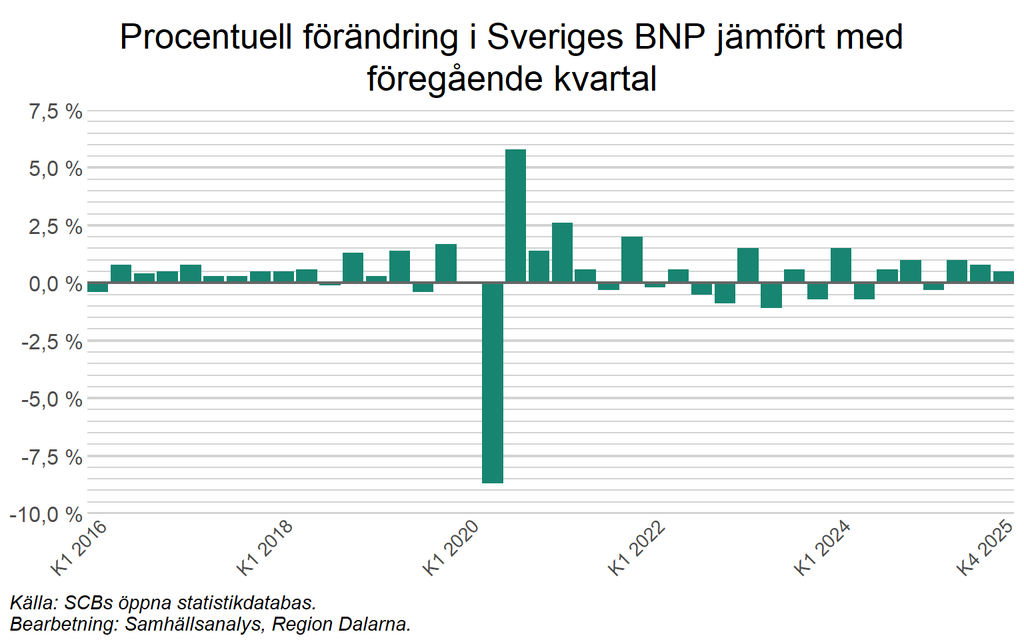

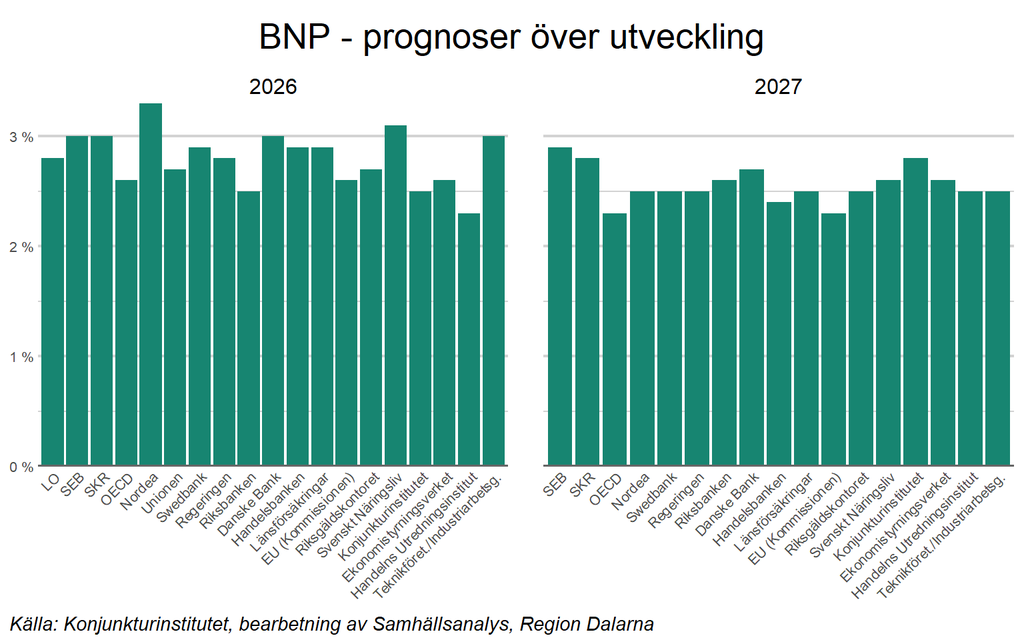

## 1.2 Konjunkturbarometern

Ett annat sätt att mäta läget i ekonomin är genom de olika enkätundersökningar som Konjunkturinstitutet regelbundet genomför, med frågor till företag och hushåll om deras uppfattning om nuläge och förväntningar på den ekonomiska utvecklingen. Svaren vägs samman i en indikator som kallas Konjunkturbarometern. Till skillnad från BNP fokuserar konjunkturbarometern inte enbart på nuläget, utan hushållen och företagen får även svara på frågor som rör framtidsutsikterna. Barometerindikatorn väger samman konfidensindikatorer från svaren i de olika enkäterna och ger varje månad en bild av konjunkturläget i Sveriges ekonomi.

**Mer information om statistiken**

Barometerindikatorn sammanfattar konfidensindikatorer för industrisektorn, tjänstesektorn, byggsektorn, detaljhandeln samt hushållen i Sverige. Indikatorerna baseras på enkätsvar från företag om bland annat deras produktion, investeringar och försäljning, men även företagens planer och förväntningar om framtiden, tillsammans med hushållens svar på enkätfrågor om deras ekonomiska situation nu och deras planer och förväntningar för framtiden. Detta sammanfattas i Konjunkturbarometern. Barometerindikatorn kan närmast jämföras med EU-kommissionens Economic Sentiment Indicator (ESI) och har ett medelvärde på 100 och en standardavvikelse på 10. Värden över 100 motsvarar en starkare ekonomi än normalt och värden över 110 en mycket starkare ekonomi än normalt. Värden under 100 respektive under 90 visar en svagare respektive mycket svagare ekonomi än normalt.

### Generellt

I mars 2026 var barometerindikatorn 99,9, vilket var i stort sett oförändrat jämfört med månaden innan. Barometerindikatorn visar på ett normalt stämningsläge i den svenska ekonomin (se [Konjunkturinstitutet](https://www.konj.se/publikationer/konjunkturbarometern/2026-03-25-fortsatt-normaltstarkt-stamningslage/)) . Att barometerindikatorn länge hade ett lågt värde kan delvis förklaras av Rysslands invasion av Ukraina och de effekter denna haft på bland annat tillgången på råvaror. Historiskt varierar barometerindikatorn med konjunkturen och större kriser i samhället, såsom finanskrisen 2008/2009 och Coronapandemin 2020/2021, syns tydligt i diagrammet.

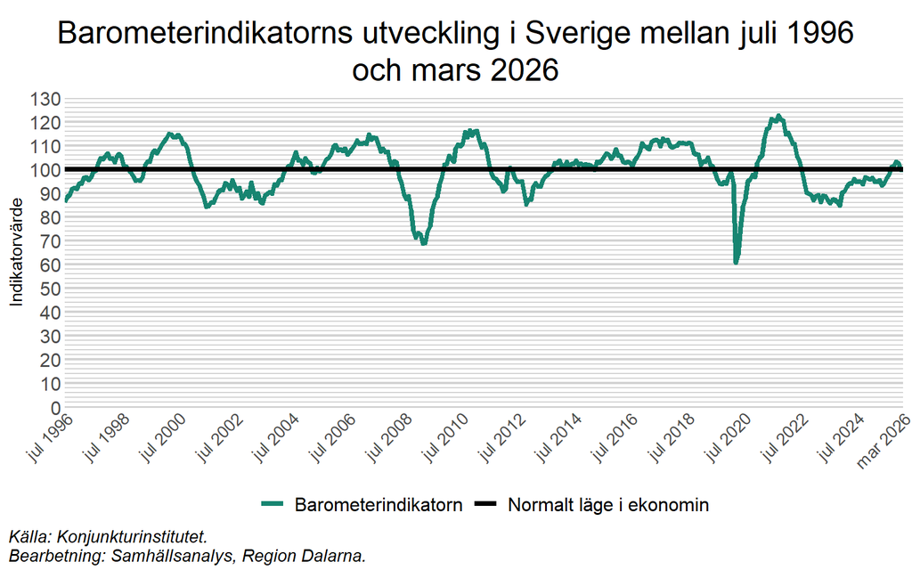

### Bransch

Hur läget i ekonomin uppfattas varierar beroende på om det är företagen eller hushållen som tillfrågas. Hushållens syn på ekonomin försämrades i mars 2026, jämfört med månaden innan (en barometerindikator på 95,2). Eftersom indikatorn understiger 100, är stämningsläget bland hushållen sämre än normalt.

Bland branschgrupperna i diagrammet nedan hade byggverksamhet den mest positiva synen på ekonomin i mars 2026 (en barometerindikator på 103,1), medan företag inom tillverkningsindustri uppfattar den ekonomiska utvecklingen som mer negativ (en barometerindikator på 100,7). Stämningsläget inom handel försvagades tydligt jämfört med månaderna innan, men kan fortfarande beskrivas som bättre än normalt (se [Konjunkturinstitutet](https://www.konj.se/publikationer/konjunkturbarometern/2026-03-25-fortsatt-normaltstarkt-stamningslage/)).

Tjänstesektorn drabbades värst under pandemin (mars/april 2020), medan tillverkningsindustrin uppfattade ekonomin som starkare än normalt från slutet av 2020 fram till mitten av 2022.

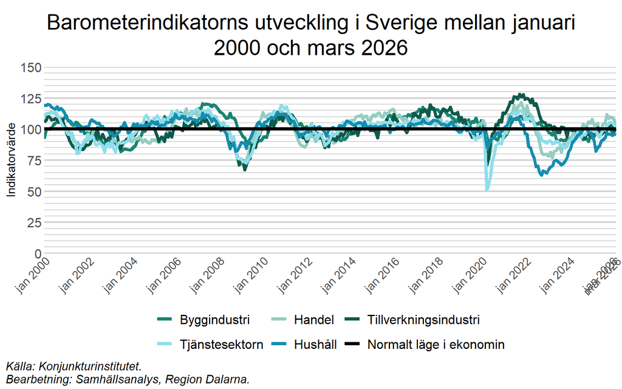

## 1.3 Inflation

Ytterligare en faktor som är viktig för ett lands ekonomi är förändringen i den allmänna prisnivån, så kallad inflation. Normalt förknippas hög inflation med problem, eftersom varor och tjänster blir dyrare. Om inte lönerna ökar i samma takt blir människor fattigare i reala termer, vilket har blivit påtagligt i Sverige de senaste åren. Även låg, eller negativ, inflation kan vara skadligt för ekonomin. Exempelvis missgynnas låntagare av en sjunkande prisnivå, då deras lån ökar i värde realt. Sveriges Riksbank strävar därför efter att hålla inflationen relativt konstant över tid, runt ett uttalat inflationsmål.

**Mer information om statistiken**

Det vanligaste och mest kända sättet att mäta inflationen på i Sverige är titta på förändringen i konsumentprisindex, KPI. Under senare tid har måttet utvecklats med att hålla räntenivån fast, då kallat KPIF. Anledningen är att räntan kan påverka prisnivån indirekt, framförallt genom boendekostnader. Konsumentprisindex med fast ränta, KPIF beräknas med samma data och på samma sätt som KPI, men utan att effekten av ändrade räntor räknas med. Indexet visar hur mycket det kostar att leva i Sverige och hur denna kostnad har utvecklats över tid. Målet för Riksbankens penningpolitik är att inflationen ska vara 2 procent. Ett viktigt skäl till den tydliga målsättningen är också att skapa trygghet och långsiktighet för företag och hushåll i deras ekonomiska beslut.

Sedan Riksbankens inflationsmål infördes 1993 har inflationen, mätt som årsförändring i KPIF, legat klart under inflationsmålet på 2 procent under långa perioder. Från sin bottennivå i april 2020 ökade dock inflationen väldigt mycket och var som högst i december 2022, då den i Sverige uppgick till 10,2 procent. Därefter minskade inflationen avsevärt och var som lägst i september 2024 (1,1 procent). I februari 2026 var inflationen 1,7 procent, vilket var lägre än månaden innan och även lägre än Riksbankens inflationsmål på 2 procent. För en mer ingående förklaring av vad som påverkade inflationstakten i februari 2026, se [SCB](https://www.scb.se/hitta-statistik/statistik-efter-amne/priser-och-ekonomiska-tendenser/priser/konsumentprisindex-kpi/pong/statistiknyhet/konsumentprisindex-kpi-februari-2026/). Riksbankschefen Erik Thédeen varnar dock för att högre drivmedelspriser till följd av kriget i Mellanöstern kan leda till en ökad inflation ([Riksbanken](https://www.riksbank.se/sv/press-och-publicerat/nyheter-och-pressmeddelanden/nyheter/2026/thedeen-buffertar-ska-vara-anvandbara/)).

Den höga inflationstakten under framförallt 2022 och 2023 har ett antal olika förklaringar, däribland begränsningar i utbudet av varor när världen öppnade upp efter Corona-pandemin och Rysslands invasion av Ukraina. Läs mer på [Wikipedia](https://en.wikipedia.org/wiki/2021%E2%80%932023_inflation_surge).

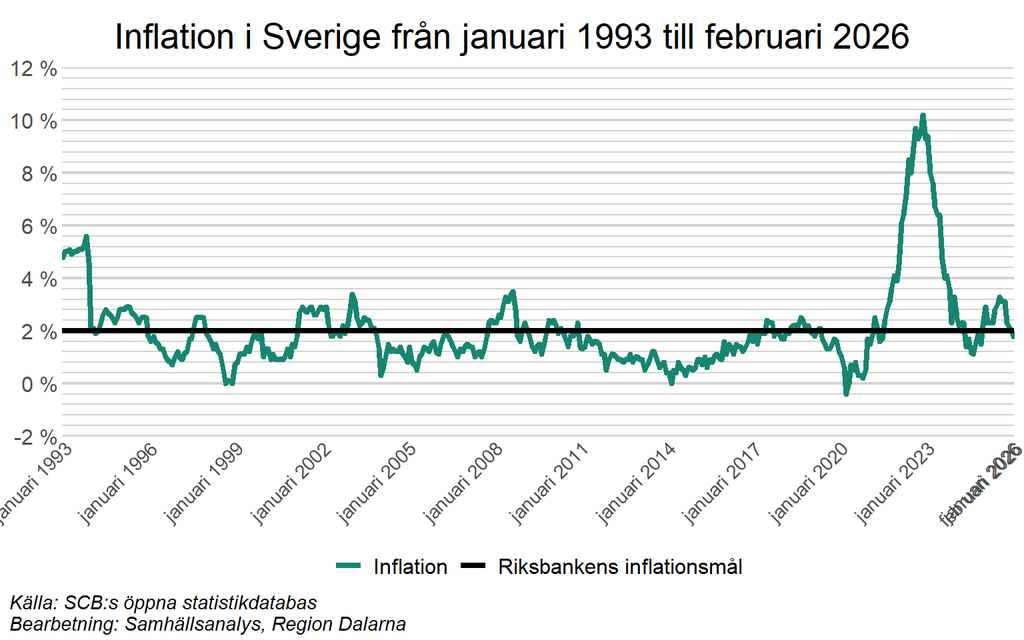

Konjunkturinstitutet sammanställer på sin [hemsida](https://www.konj.se/publikationer/prognosjamforelse/) ett urval av aktuella prognoser för inflation (enligt KPIF). För år 2026 är det vissa skillnader mellan prognoserna, men en majoritet av prognosinstituten tror att inflationen enligt KPIF kommer att vara mellan 1 och 1,5 procent, vilket är lägre än Riksbankens inflationsmål. Året efter är det mindre skillnader mellan prognoserna och uppfattningen är att inflationen kommer att vara något högre än under 2026 (mellan 1,5 och 2 procent).

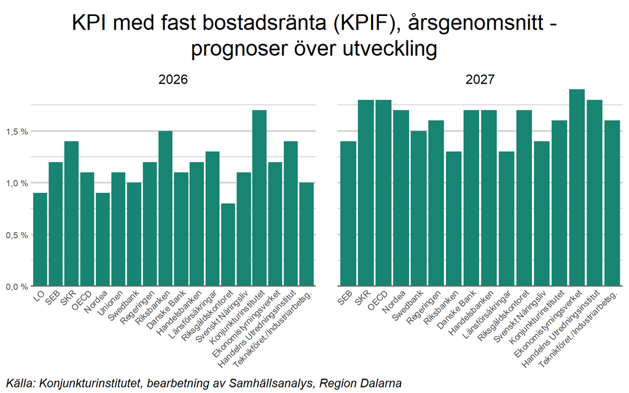

Sedan sommaren 2024 har Riksbanken sänkt sin styrränta åtta gånger (den ligger nu på 1,75 procent). Detta påverkar [räntorna](https://www.scb.se/hitta-statistik/statistik-efter-amne/finansmarknad/finansmarknadsstatistik/finansmarknadsstatistik/pong/statistiknyhet/finansmarknadsstatistik-augusti-2025/) på exempelvis bostadslån. I jämförelse med framförallt andra hälften av 2010-talet är dock styrräntan fortfarande relativt hög (se exempelvis [Ekonomifakta](https://www.ekonomifakta.se/sakomraden/finansiell-ekonomi/inflation-och-styrrantor/styrrantan_1208883.html)). Räntan förväntas ligga kvar på denna nivå en tid framöver, men kriget i Mellanöstern gör prognosen mycket osäker ([Riksbanken](https://www.riksbank.se/sv/press-och-publicerat/nyheter-och-pressmeddelanden/pressmeddelanden/2026/styrrantan-oforandrad-pa-175-procent2/)).

# 2 Bostadsmarknaden

2010-talet kännetecknades av en bostadsmarknad där det mesta pekade uppåt. Låg inflation och låga räntor i kombination med fördelaktiga skatteregler medförde att såväl byggandet av bostäder, som bostadspriserna ökade kraftigt. Nationellt har bostadslånen ökat under en lång period och uppgick i Sverige år 2024 till ungefär 160 procent av hushållens disponibla inkomst, vilket är nästan dubbelt så stor andel som under mitten av 1990-talet. Samtidigt har hushållen i Sveriges finansiella tillgångar ökat, vilket medfört att skulderna i relation till de finansiella tillgångarna minskat något under samma tidsperiod [(SCB)](https://www.scb.se/hitta-statistik/temaomraden/sveriges-ekonomi/konjunkturindikatorer/finansmarknad/#62307). Det kan naturligtvis finnas skillnader regionalt, men vi saknar data för detta i nuläget.

## 2.1 Bostadsbyggande

**Mer information om statistiken**

Småhus definieras som friliggande en- och tvåbostadshus samt par-, rad- och kedjehus (exklusive fritidshus).

Notera att det finns en eftersläpning i statistiken. För bygglov gör eftersläpningen att de senaste fyra kvartalens siffror är underskattade. Störst är underskattningen det senaste kvartalet.

För påbörjade småhus är statistiken preliminär och underskattningen det senaste kvartalet mellan 20 och 60 procent beroende på kvartal. Underskattningen är som störst för andra kvartalet. Efter ett år är underskattningen cirka 2 procent

### Bygglov

Antalet godkända bygglov för småhus i Dalarna varierar mellan kvartalen, men sedan toppen i kvartal två 2022, då 147 bygglov godkändes, har antalet godkända bygglov minskat och i kvartal fyra 2025, godkändes 55 bygglov. Detta var dock fler än motsvarande kvartal föregående år. Notera dock att det finns en eftersläpning i statistiken, se “Mer information om statistiken” ovan.

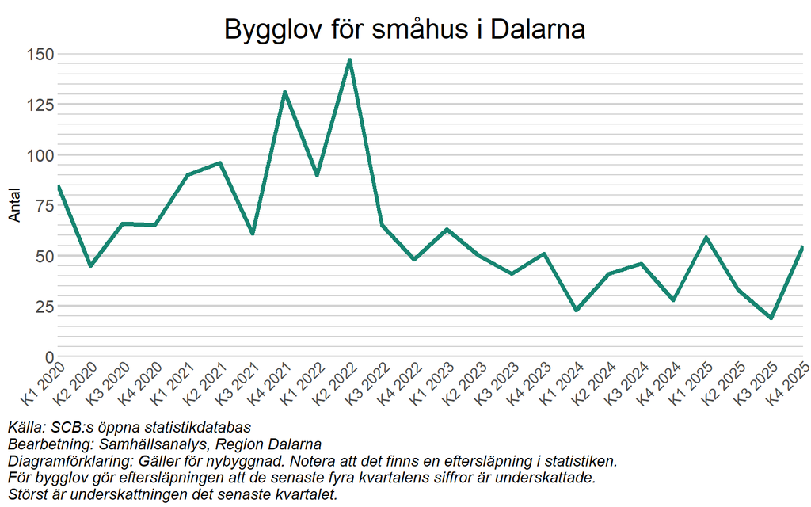

### Nybyggnation

Precis som för byggloven, varierar byggandet av småhus mellan kvartalen, men en långsiktig trend är att byggandet har minskat tydligt från toppen i kvartal två 2022, då 136 småhus påbörjades, till kvartal fyra 2025, då 17 småhus påbörjades. Notera dock att det finns en eftersläpning i statistiken, se “Mer information om statistiken” ovan.

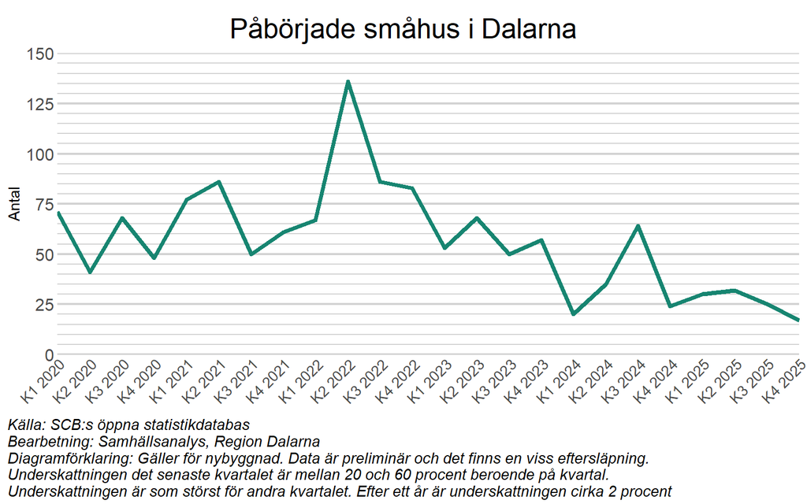

## 2.2 Bostadspriser

**Mer information om statistiken**

Noteringen om månad avser i själva verket en tremånadersperiod, där noteringen avser den sista månaden i perioden.

### Historisk jämförelse

Priserna på småhus ökade stadigt under en lång period, såväl i Dalarna som i Sverige. Efter toppen i januari 2022, då ett småhus i Dalarna kostade ungefär 3 miljoner kronor, har dock det genomsnittliga priset på småhus i länet minskat avsevärt och en botten nåddes i oktober 2023, när ett småhus i Dalarna kostade strax under 2,1 miljoner kronor i genomsnitt. Den tydliga minskningen kan delvis förklaras av Rysslands invasion av Ukraina, vilken bland annat medförde en kraftigt ökad inflation med efterföljande räntehöjningar, något som påverkar efterfrågan på bostäder.

Sedan 2023 har priserna på småhus i Dalarna delvis återhämtat sig och var i februari 2026 ungefär 2,3 miljoner kronor (i genomsnitt), vilket var något högre än månaden innan.

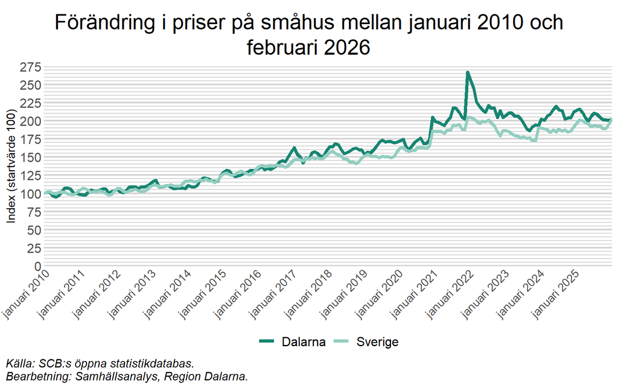

### Län

Det genomsnittliga priset på ett småhus varierar mellan Sveriges län och var i februari 2026 högst i Stockholm, där ett småhus i genomsnitt kostade 7 miljoner kronor. I Dalarna är priset klart lägre, ett småhus kostar i genomsnitt ungefär 2,3 miljoner kronor i länet. Av förklarliga skäl är bostadspriserna generellt högst i län med större städer där befolkningen växer, medan det omvända gäller för län med en mindre befolkning.

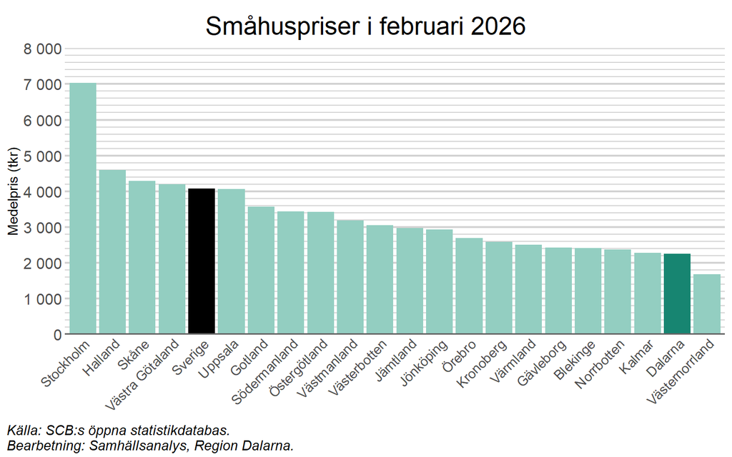

# 3 Företagandet

Läget för företagen i länet hänger naturligtvis samman med läget i ekonomin i stort. Vid sämre tider konsumerar hushållen mindre och efterfrågan på många företags produkter och tjänster minskar, vilket i förlängningen kan leda till att företag begärs i konkurs eller avregistreras. Det är även möjligt att sämre tider medför att det blir mindre attraktivt att starta nya företag.

I det här avsnittet undersöks först hur många nya företag som startas i Dalarna, därefter analyseras hur många anställda som berörs av konkurser i länet och hur många företag som avregistreras.

## 3.1 Nystartade företag

**Mer information om statistiken**

Statistiken beskriver mängden genuint nystartade företag. Med genuint nystartade företag menas företag som är helt nybildade eller har återupptagits efter att ha varit vilande i minst två år. Företag som nyregisteras på grund av ägarskiften, ändring av juridisk form eller annan ombildning exkluderas. Från och med 2011 är statistiken registerbaserad.

Historiskt startades väldigt många företag i samband med Corona-pandemin 2020-2021. I kvartal två 2021 startades exempelvis 506 företag, vilket var det största antalet sedan åtminstone 2011. Exakt vad detta beror på kan vara svårt att säga, men en potentiell förklaring är att individer som blev uppsagda under pandemin valde att starta egna företag. Någon större trend sedan Rysslands invasion av Ukraina märktes inte initialt för antalet nystartade företag. Under 2022 startades till och med något fler företag än genomsnittet sedan 2011. Under första halvan av 2023 märktes en viss avmattning dock, innan antalet nystartade företag återigen började öka. I kvartal fyra 2025 startades 407 företag, vilket var 33 färre än föregående kvartal.

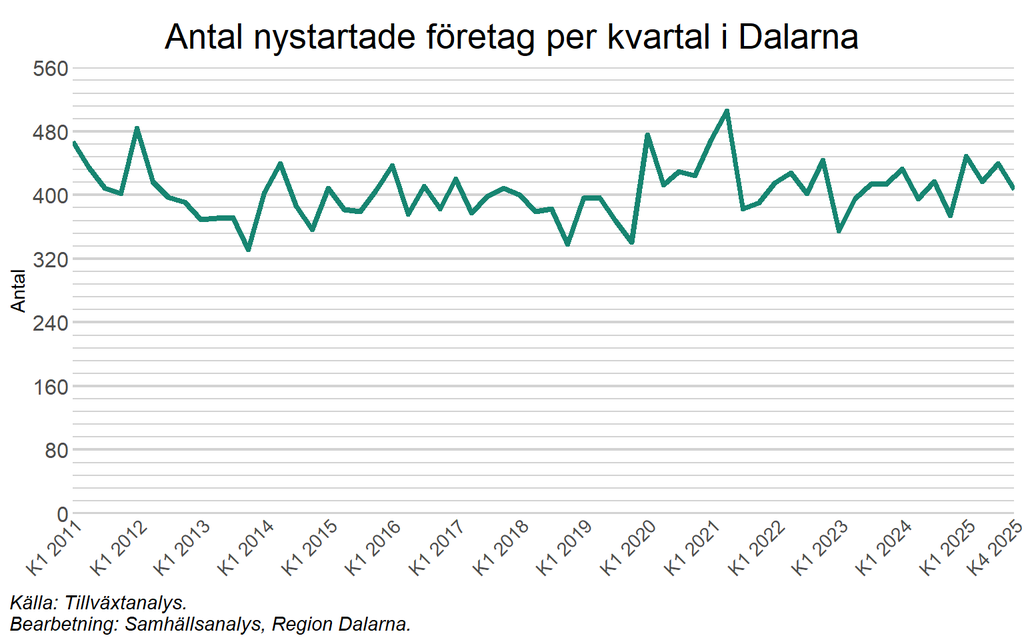

## 3.2 Konkurser

### Månad

Antalet anställda som berörs av konkurser varierar relativt mycket från månad till månad, vilket medför att det kan var svårt att se någon trend på månadsbasis kopplad till exempelvis Rysslands invasion av Ukraina och dess effekter på Dalarnas ekonomi.

Efter att ha ökat tydligt i januari 2025, då närmare 150 personer berördes av konkurser i Dalarna, minskade exempelvis antalet anställda som berördes av konkurser i februari och mars 2025, jämfört med samma period föregående år. Därefter såväl ökade som minskade antalet anställda berörda av konkurser under 2025 jämfört med motvarande månader föregående år, vilket gör det svårt att utröna någon tydlig trend.

I februari 2026 berördes 18 anställda av konkurser, vilket dock var färre än de 33 anställda som berördes motsvarande månad 2025.

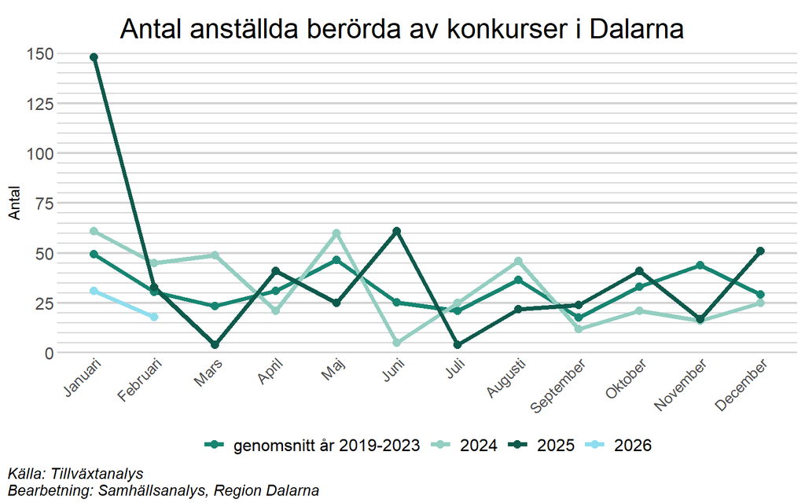

### År

Hittills under 2026 har 49 anställda berörts av konkurser i Dalarna, vilket är klart färre än de 181 som berördes under motsvarande period 2025.

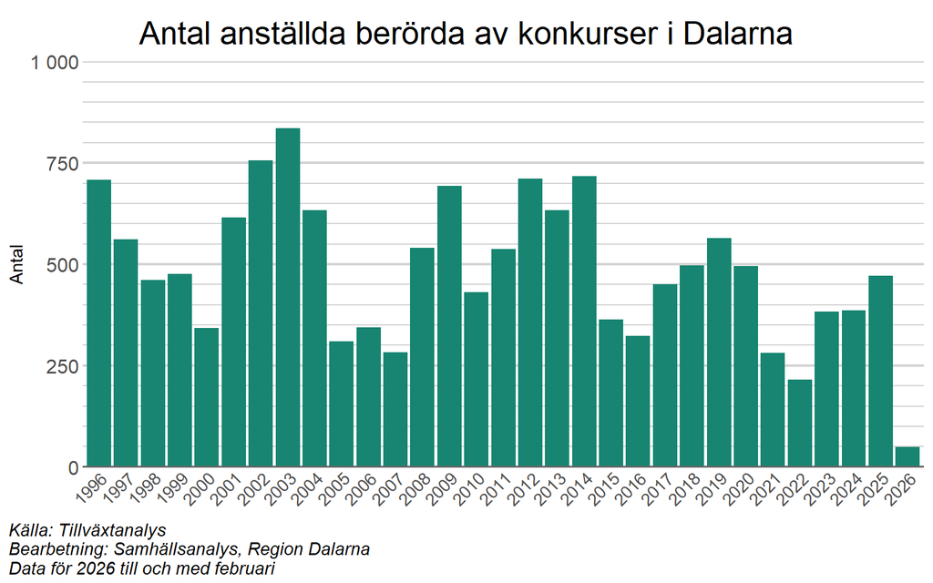

## 3.3 Avregistrerade företag

Ett potentiellt alternativ till att begära ett företag i konkurs är att istället avregistrera det. Antalet avregistrerade företag tenderar att följa ett visst säsongsmönster, med fler avregistreringar i början och slutet av året. Det är dock svårt att se någon långsiktig trend, då ungefär lika många företag (drygt 1000) avregistreras varje år. Undantaget var 2021, när drygt 1200 företag avregistrerades. Detta verkar i första hand bero på att många företag avregistrerade i januari 2021, av oklar anledning.

I februari 2026 avregistrerades 52 företag i Dalarna, jämfört med 69 samma månad året innan.

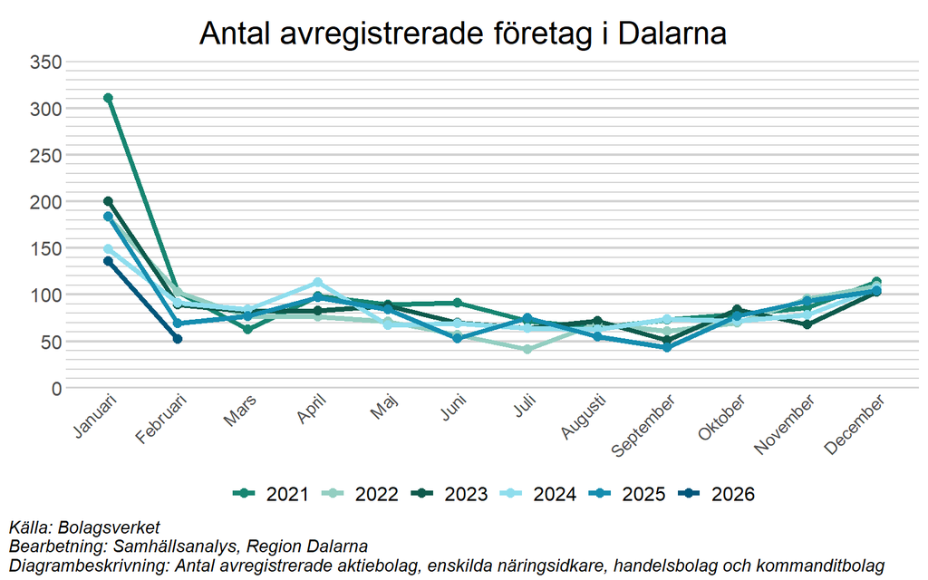

# 4 Arbetsmarknaden

Som mått på läget i Dalarna, är arbetslösheten sannolikt en relativt trögrörlig indikator. Detta eftersom företag i första läget varslar personal, för att därefter eventuellt göra större uppsägningar. De är även viktigt att notera att arbetslösheten varierar mellan olika grupper i samhället, exempelvis baserat på personers kön, utbildningsbakgrund eller huruvida de är födda i Sverige. För en fördjupad diskussion runt detta, se exempelvis Region Dalarnas rapport [“Kvinnor och män i Dalarna”](https://samhallsanalys.regiondalarna.se/kvinnor_man).

## 4.1 Arbetslöshet

**Mer information om statistiken**

Arbetslöshet beräknas som andelen arbetslösa i förhållande till antalet personer i arbetskraften, det vill säga summan av antalet arbetslösa och antalet sysselsatta. Statistik över arbetslöshet och sysselsättning kan tas fram på olika sätt. Det gör att siffror som rör samma referensperiod kan skilja sig åt beroende på vilken statistikkälla som använts. I den här rapporten används BAS - befolkningens arbetsmarknadsstatus - som redovisar registerbaserad statistik över utbudet av arbetskraft i Sverige. För en diskussion runt skillnaderna mellan BAS och Arbetsförmedlingens statstsik, se [SCB](https://www.scb.se/contentassets/f5d14c6270b746f6af4e5ef37886704f/en-numerisk-beskrivning-av-relationen-mellan-bas-och-arbetsformedlingens-statistik.pdf).

### Län

I en nationell jämförelse är arbetslösheten i Dalarna relativt låg. I januari 2026 hade Dalarna 4,4 procents arbetslöshet, att jämföra med 5,8 procent i Sverige som helhet. Noterbart är även att Dalarna har klart lägre arbetslöshet än näraliggande Gävleborg, där arbetslösheten var 7 procent under samma tidsperiod. Lägst arbetslöshet i Sverige hade Norrbotten med 3,2 procent.

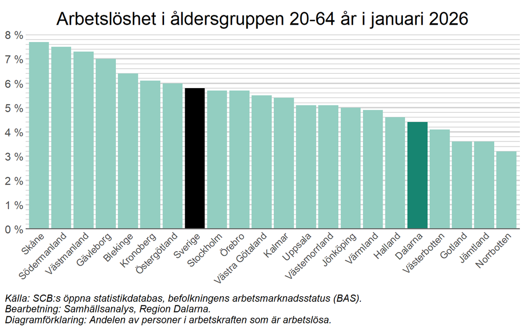

### Jämförelse över tid

Arbetslösheten, såväl i Dalarna som i Sverige, varierar över tid. I samband med pandemin orsakad av Covid-19, ökade arbetslösheten och var som högst i Dalarna i februari 2021, då den uppgick till 6,5 procent. Därefter har arbetslösheten minskat och var i januari 2026 4,4 procent i Dalarna.

Under stora delar av 2025 var arbetslösheten i Dalarna på ungefär samma nivå som motsvarande perioder 2023 och 2024, men mot slutet av året var den något lägre. Denna trend fortsatte i januari 2026, då arbetslösheten var lägre än motsvarande månader åren innan.

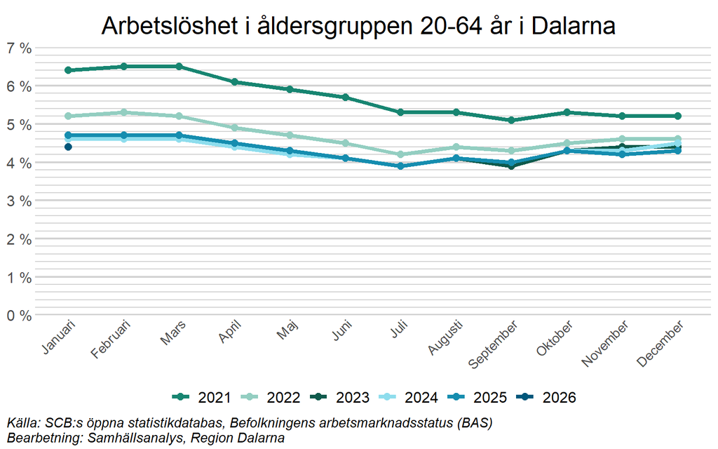

Om arbetslösheten delas upp i inrikes och utrikes födda framträder en delvis annorlunda bild. Bland inrikes födda (det vänstra diagrammet nedan) var arbetslösheten något högre under 2025 jämfört med åren innan under stora delar av året . I januari 2026 var arbetslösheten bland inrikes födda 3 procent i Dalarna, vilket dock var lägre än motsvarande månad året innan (men högre än 2024 och 2023). Bland utrikes födda (det högra diagrammet nedan) har arbetslösheten fortsatt att minska stadigt under samma tidsperiod, men är klart högre än bland inrikes födda (11,9 procent i januari 2026).

Totalt var 3 193 inrikes födda personer och 2 425 utrikes födda personer i åldersgruppen 20-64 år arbetslösa i Dalarna i januari 2026.

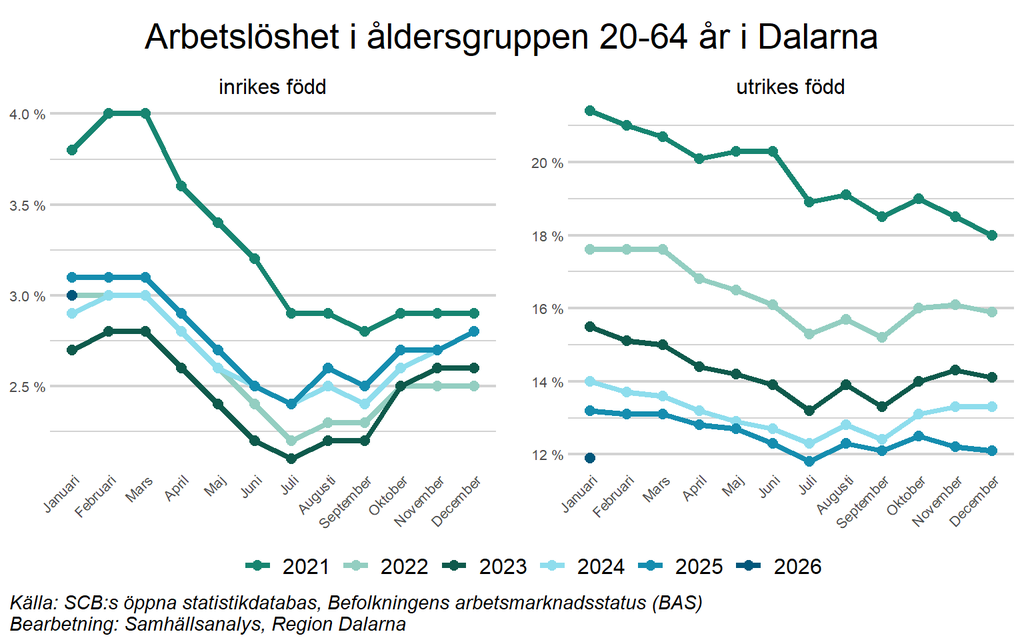

### Kommun

Arbetslösheten bland Dalarnas kommuner är låg på många håll, där en majoritet av länets kommuner hade mellan 2 och 4 procents arbetslöshet i januari 2026. Lägst är arbetslösheten i Malung-Sälen, med 2,3 procent. I de södra delarna av länet är bilden delvis annorlunda, där kommunerna generellt har högre arbetslöshet. Högst är arbetslösheten i Avesta, där den uppgår till 6,9 procent. En tänkbar orsak till detta mönster är att de kommuner med högst arbetslöshet också är de kommuner som har högst andel utrikes födda. Den sistnämnda gruppen tenderar att hamna i arbetslöshet i högre utsträckning än inrikes födda.

[interactive chart not shown]

# 5 Befolkningens ekonomi

Befolkningens ekonomiska situation kan mätas på flera olika sätt. Arbetslösheten, som diskuterades i föregående avsnitt, är en indikator. Personer som arbetar har helt enkelt en bättre ekonomi än personer som inte gör det. En annan indikator är den disponibla inkomsten, dvs. hur mycket varje person har i plånboken (inkomst efter skatt och transfereringar). Tyvärr mäts den disponibla inkomsten med en betydande eftersläpning, varför vi i denna rapport istället valt att fokusera på hur många individer som har svårt att försörja sig, mätt i antalet personer som har ekonomiskt stöd som huvudsaklig inkomstkälla.

## 5.1 Ekonomiskt stöd

**Mer information om statistiken**

Med ekonomiskt stöd åsyftas försörjningsstöd och bistånd till livsföringen i övrigt för sökande och eventuell medsökande, bostadsbidrag för sökande och eventuell medsökande samt äldreförsörjningsstöd.

I Dalarna hade som mest närmare 5000 personer mellan 15 och 74 år ekonomiskt stöd som huvudsaklig inkomstkälla under 2020, men därefter minskade antalet stadigt under en längre period. Anmärkningsvärt är även att behovet av stöd minskade trots att prisnivån i samhället ökade avsevärt under samma tidsperiod (se avsnittet om inflation). Exakt vad den utvecklingen beror på är oklart, men ett antal tänkbara orsaker diskuteras i följande [artikel](https://www.svt.se/nyheter/inrikes/darfor-minskar-antalet-hushall-som-far-socialbidrag-i-sverige-forskare-forklarar-orsaker-bakom).

Antalet personer som har ekonomiskt stöd som huvudsaklig inkomstkälla varierar en del mellan månaderna, men under 2025 var trenden nedåtgående jämfört med föregående år. I januari 2026 hade 3 170 personer ekonomiskt stöd som huvudsaklig inkomstkälla, vilket var färre än månaden innan.

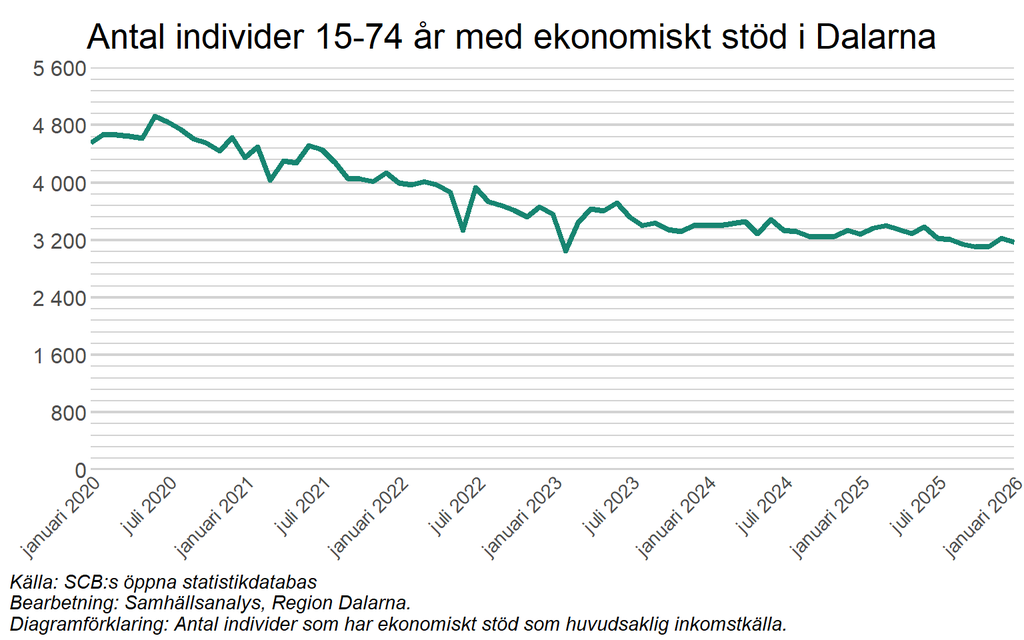

Om antalet individer delas upp i inrikes och utrikes födda, blir det tydligt att nedgången i antalet med ekonomiskt stöd som huvudsaklig inkomstkälla framförallt är koncentrerad till utrikes födda. I januari 2020 hade ungefär 830 fler utrikes födda personer i Dalarna ekonomiskt stöd som huvudsaklig inkomstkälla, jämfört med inrikes födda. I januari 2026 hade lika många utrikes som inrikes födda personer ekonomiskt stöd som huvudsaklig inkomstkälla.

Ett annat generellt mönster är att det bland inrikes födda är vanligare att män har ekonomiskt stöd som huvudsaklig inkomstkälla, medan det bland utrikes födda är vanligare att kvinnor har det. I januari 2026 hade ungefär 680 inrikes födda kvinnor och ca 910 inrikes födda män ekonomiskt stöd som huvudsakliga inkomstkälla. Bland utrikes födda var motsvarande antal ca 1000 kvinnor och ungefär 590 män.

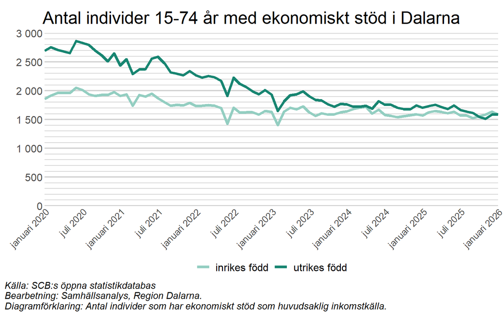